# Survey Text Analysis

2020-11-01

## Purpose

The purpose of this analysis is to analyze the four open ended questions in a survey for customer satisfaction for VHT’s products.

The four questions are:

1. If you could change anything about the services VHT Studios offers, what would it be? Tagged as “Change 1 thing” in dataset.
2. What can we do better? Tagged as “do better” in dataset.
3. What other capabilities would you be interested in VHT offering? Tagged as “Other Services” in dataset.
4. Additional Comments and/or Suggestions for improvements or changes. Tagged as “Other Comments” in dataset.

## Most Common Words Overall

First, I look at the most common words overall. Note, stop words are removed. Stop words are extremely common words like “and”, “a”, and “the” and offer no meaning for analytical purposes.

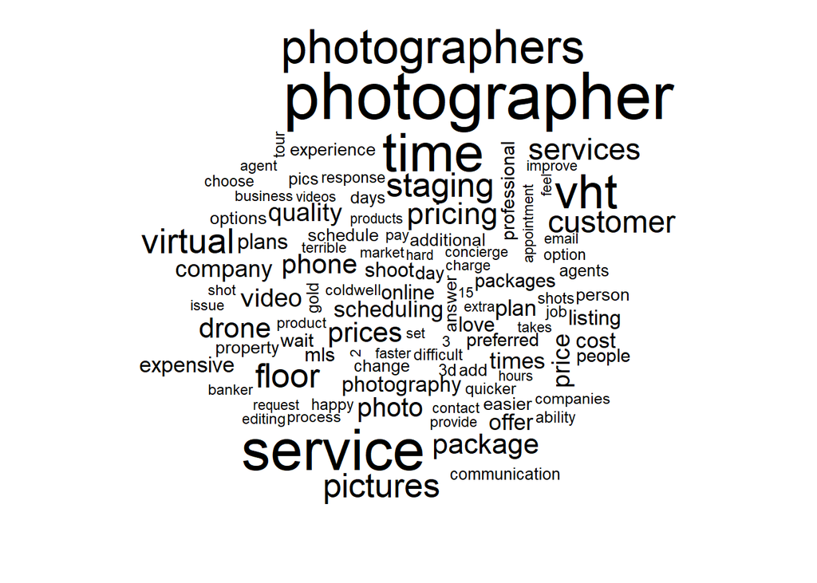

The wordcloud above shows the top 100 words used by the respondents. Photographer is the most frequent word, which really isn’t a big surprise, but some other interesting ones are ‘service’, ‘time’,‘pricing’ and ‘quicker’.

## Single Word Sentiment Wordcloud

Below, the top 150 words are visualized based on sentiment.

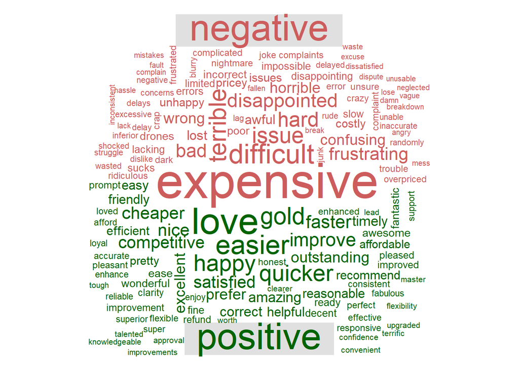

## Visualize Most Common Single Words by Question

The below image shows the single most frequent words that appear on each of the four open ended questions.

Some observations:

1. Pricing seems to be pretty popular in the “change 1 thing” question as it appears twice, as price and pricing.
2. Photos appears the most times in both the “change 1 thing” and “do better” questions. That would be something else to explore.
3. The “other services” questions has some interesting words, like video and drone. Both are services offered so it would be interesting to see the context.

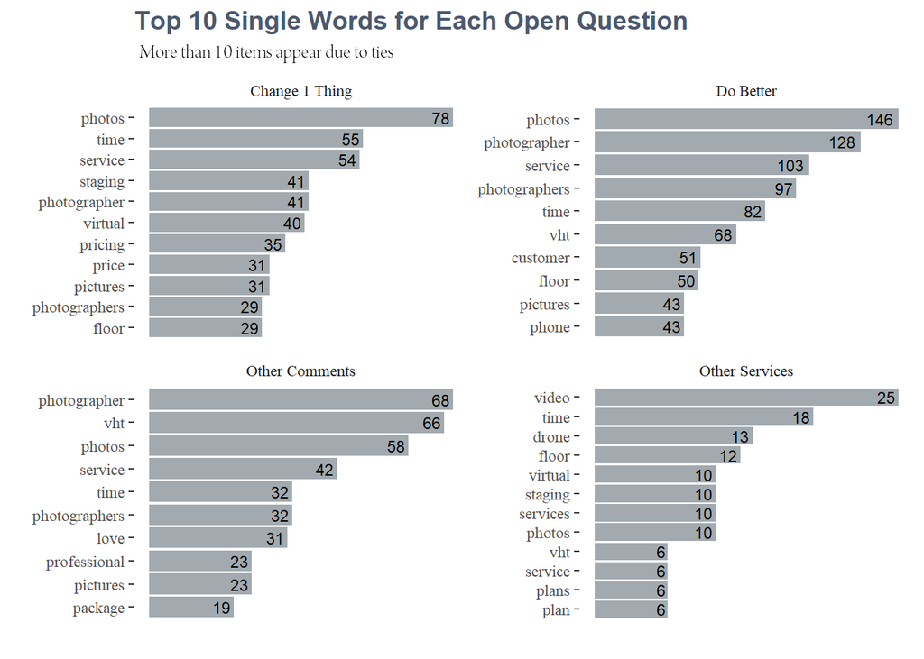

## Common Bigrams - Two words that appear side by side

The next section will show two words that often appear together. Note, bigrams appear less frequently than single words so counts will be lower.

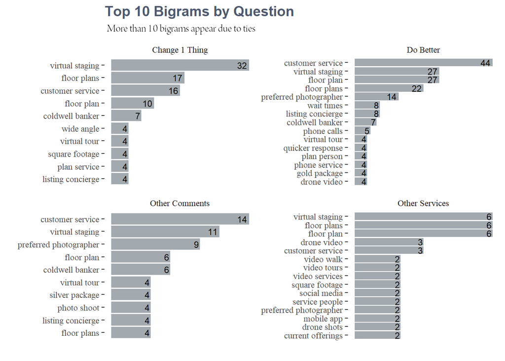

Bigrams are a little more interesting than unigrams because you can start to see some context around the verbage in the responses.

1. Virtual staging appers most frequently in the “change 1 thing” and other services questions, while it is second place in the “do better” and “other comments” questions.
2. “Gold package” makes the top 10 in the “do better” question.
3. “Customer service” is number 1 in “do better”
4. “Floor plan(s)” appears twice in the “change 1 thing” question

## Sentence Sentiment

Lookng at the sentiment of individual words is a bit too primitive and the English language is syntactically complex and lexically rich so now I will take a look at the sentiment of full responses.

The algorithm I will use is a bit better than sentiment by word. It uses “valence shifters” that help adjust the sentiment score. For example, if you do sentiment analysis on the single word “happy”, the score is positive. Obviously though, if the phrase is “not happy” it is no longer positive but a single word sentiment analysis would not pick that up. The valence shifters will help adjust “not happy” to negative or at least less positive. Also, the sentiment score that will be returned will be an aggregate of each sentence for each question and response. That way we only look at a single score per question and response. A score greater than 0 implies an overall positive sentiment.

A note on sentiment, it is not a perfect process. Words are normally crowdsourced to see if they are positive or negative, so the context a word is used may not be included. A good example is the word “plot”. A movie plot is a positive word, but a plot to do a bad deed is negative.

A more specific example for this dataset is this response:

“$150 for 20 photos is a lot of money when we can get cheaper pricing in our area.”

This is scored as 0.4 which is a positive score but it isn’t a positive response by the recipient.

In the table below you can search both by score and whether the sentiment is positive or negative.

|  | question | sentence | Avg Sentiment | Sentiment |
| --- | --- | --- | --- | --- |
| 1 | Change 1 Thing | $150 for 20 photos is a lot of money when we can get cheaper pricing in our area. | 0.4 | positive |
| 2 | Change 1 Thing | - less expensive view shots and included in the silver virtual staging is way overpriced scheduling system is an albatross i wish you could send an email blast to all the realtors in the space coast r… | -0.13 | negative |
| 3 | Change 1 Thing | 0 communications i liked when i called it just went straight to megan. | 0.32 | positive |
| 4 | Change 1 Thing | 1) less expensive virtual staging 2) customer service hours on the weekend i prefer receiving photos in a jpg. | 0.11 | positive |
| 5 | Change 1 Thing | 1)the turnaround time for error corrections needs improvement. | -0.09 | negative |
| 6 | Change 1 Thing | 2)the presentation of the new floor plans could be improved. | 0.49 | positive |
| 7 | Change 1 Thing | 3) we used to be able to get reliable square footage totals. | 0.15 | positive |
| 8 | Change 1 Thing | 3d had rules like not shooting outside. | 0.04 | positive |
| 9 | Change 1 Thing | 3d tours with captions i had to go back and forth too many times and long wait. | -0.55 | negative |
| 10 | Change 1 Thing | 4 bed homes don’t require photos of all 4 bedrooms better follow up and photography. | 0.28 | positive |

[output cut: 1676 more lines]

## Keyword Search

In the table below, you can search for a keyword and find the responses that include that word and read the full responses.

|  | question | text |
| --- | --- | --- |
| 1 | Change 1 Thing | Some challenges in down loading photos. That could just be the user! |
| 2 | Do Better | I would appreciate 15 photos vs. 10 and I would prefer all shots be of the GOLD standard without the price up-charge since I am a loyal customer. |
| 3 | Change 1 Thing | That all photos be of superior quality and a package of 15 vs. 10. |
| 4 | Other Services | The ability for the agent to virtually stage a property on our own time for no additional cost. |
| 5 | Other Comments | I am happy with the turn-a-round time but don't always feel like more than one person proofed or improved a photo. I have to ask more times than I'd like for a photo to be clearer/less blurry or strai… |
| 6 | Change 1 Thing | Expand the slide show capabilities with different kinds of wipes/dissolves &amp; music choices. |
| 7 | Other Services | Not sure if an mobile app would be worthwhile as I always auto-order photos while entering a new listing on my laptop (and which can't be done well on a phone) |
| 8 | Do Better | Pricing is too high |
| 9 | Change 1 Thing | lower pricing of HD Photo's |
| 10 | Other Comments | Have photographers go slowing while working in the home - some times things need to be moved for the best photos. |

[output cut: 1772 more lines]

## Topic Modeling

The last section uses an algorithm to try to pick out common topics within each question. A popular machine learning logarithim will be used to try to discover themes within each of the four questions.

Latent Dirichlet allocation (LDA) is a popular method for fitting a topic model. It treats each question as a mix of topics, and each topic as a mixture of words. This allows documents to “overlap” each other in terms of content, rather than being separated into discrete groups, in a way that mirrors typical use of natural language.

So, the algorithm groups words, based on probability of words appearing in each of the topic or themes.

### Change 1 Thing Question

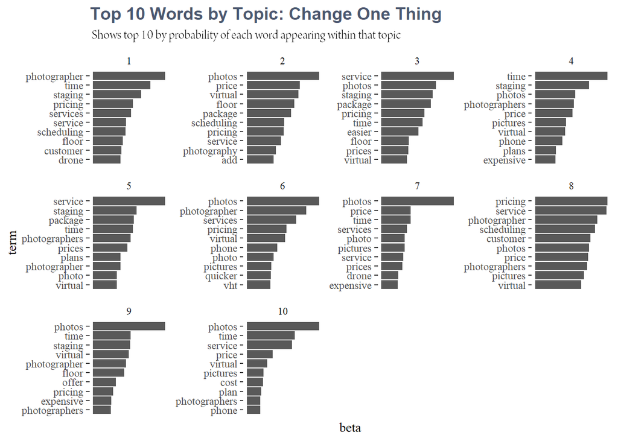

The beta on the x-axis is the probability of the word appearing on the y-axis

Some insights on change 1 thing:

1. Photos/photographers appear everything, which makes sense based on the business that the responses are for
2. Pricing/price appears to appear in all 10 topics, which also makes sense because it was a very common word.
3. Topics 7 and 9, in particular seem to be related to the expense of drones (topic 7) and virtual staging (topic 9)
4. Topic 5 seems to be related to service and time, which seems like it could be response time.
5. Topic 8 is very focused on price, but also scheduling.

### What Could Be Done Better Question

Below is the topics created for the “what could we do better question?”

Some insights:

1. Topic 1: ‘Drone’ appears at the top of the list and near the top in topic 3. Topic 1 though seems to show that people are not happy with the drone service because of prices/time/difficult but also shows customer service as being a popular topic.
2. Topic 5 and to a lesser extent 4, seems to show that quality of photos and photographers is a popular topic. This makes some sense because there were comments on how good the photo service is.
3. Pricing seems to be popular amongst the topics
4. I was curious to see if the gold or silver packages would be a popular topic. Only topic 9 references “package” but I don’t know if that references them or not. So, it could be good that the gold and silver packages do not appear in any of the topics.

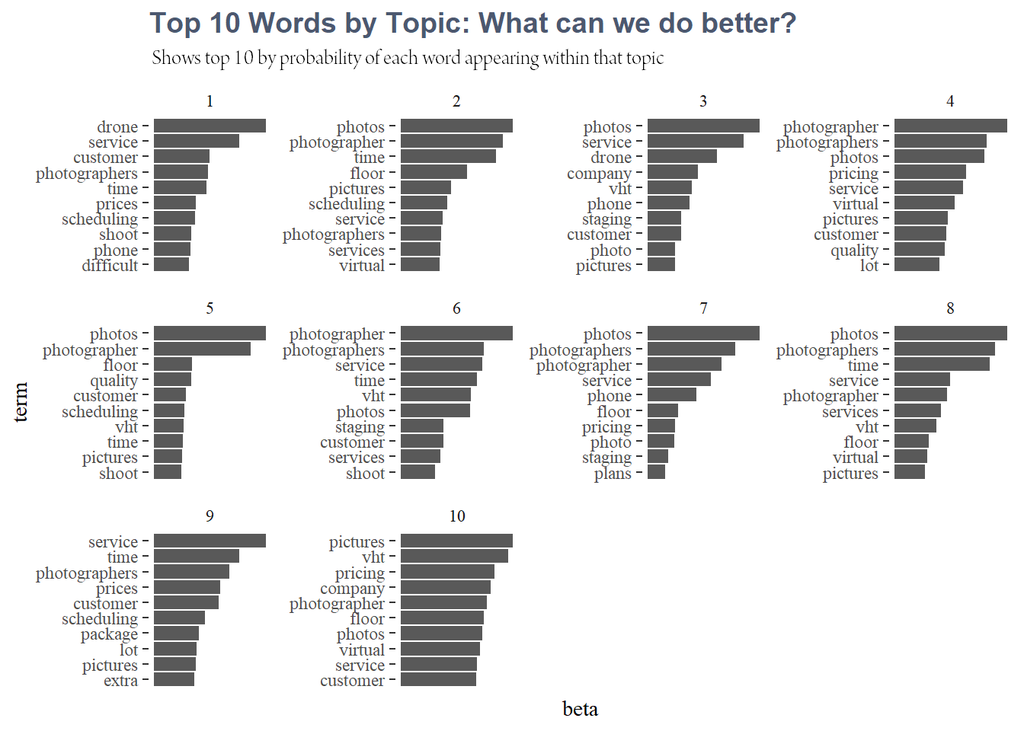

### Other Services Question

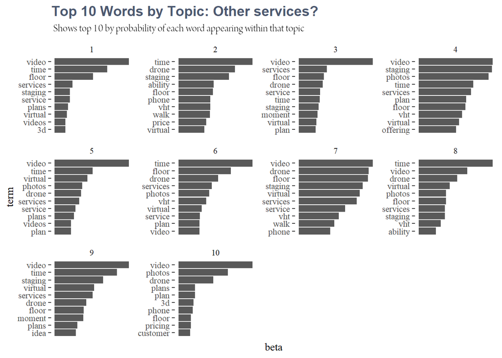

### Other Comments

Insights from the ‘other comments’ question:

1. Topic 10 refers to pricing, drones and packages which were common words that from previous analysis sections so it appears pricing definitely a popular topic.
2. Topic 2 talks about VHT, service and professionalism. This looks like a positive topic.
3. Topic 3 also seems like a positive topic since it references love and VHT.
4. Topic 4 seems like it is a positive topic for the pictures/photographers as well
5. The word ‘love’ appears in many of the topics, which could imply that overall, people are happy with the services.

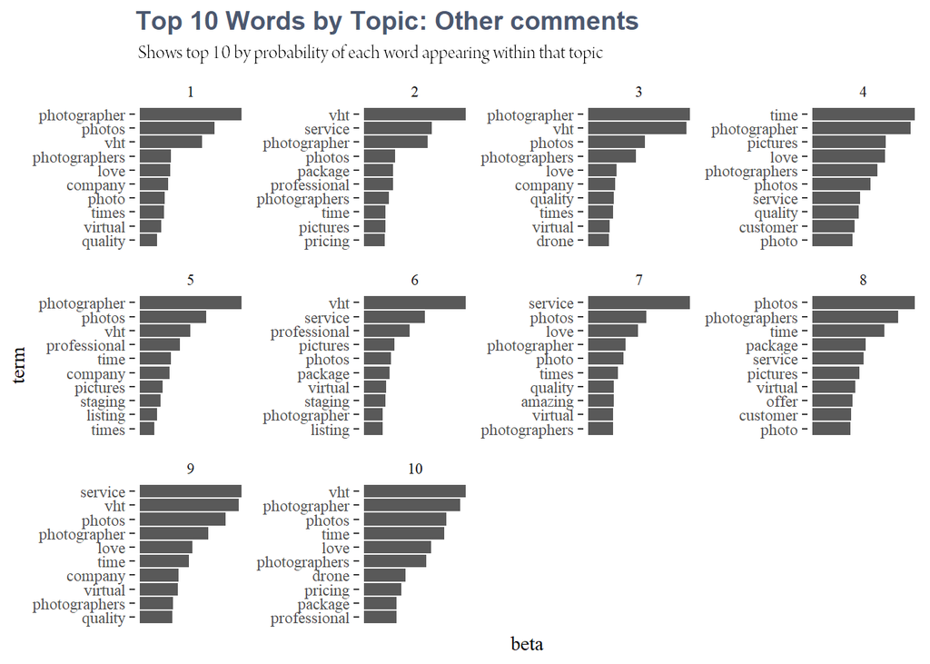